# Predictive Coverage Assessment

A well-calibrated model should produce prediction intervals whose empirical coverage matches their nominal level. The `predictive_coverage()` function computes simulation-based prediction intervals for fitted EGPD models and reports their empirical coverage. This vignette demonstrates its use for all three fitting approaches — `egpd()`, `gamlss()`, and `bamlss()` — and shows how to construct calibration plots that compare nominal and empirical coverage across a range of levels.

## Setup

```r
library(egpd)
library(gamlss)
library(bamlss)
```

## 1. Simulate data

We simulate 1000 observations from a discrete EGPD Model 1 with known parameters. Using the same data for all three fits allows a fair comparison.

```r
set.seed(42)
n <- 1000
sigma_true <- 3
xi_true    <- 0.15
kappa_true <- 2

y <- rdiscegpd(n, sigma = sigma_true, xi = xi_true,
               kappa = kappa_true, type = 1)
df <- data.frame(y = y)

cat("n =", n, "\n")
```

```
#> n = 1000
```

```r
cat("Range:", range(y), "\n")
```

```
#> Range: 0 38
```

```r
cat("Mean:", round(mean(y), 2), "\n")
```

```
#> Mean: 4.73
```

## 2. Fit models

### egpd

```r
fit_e <- egpd(list(lsigma = y ~ 1, lxi = ~ 1, lkappa = ~ 1),
              data = df, family = "degpd", degpd.args = list(m = 1))
summary(fit_e)
```

```
#>
#> ** Parametric terms **
#>
#> logscale
#>             Estimate Std. Error t value Pr(>|t|)
#> (Intercept)     1.14        0.1   11.58   <2e-16
#>
#> logshape
#>             Estimate Std. Error t value Pr(>|t|)
#> (Intercept)    -2.12       0.36   -5.87 2.23e-09
#>
#> logkappa
#>             Estimate Std. Error t value Pr(>|t|)
#> (Intercept)     0.63       0.09    7.33 1.17e-13
#>
#> ** Smooth terms **
```

### gamlss

```r
fit_g <- gamlss(y ~ 1, sigma.formula = ~ 1, nu.formula = ~ 1,
                data = df, family = DEGPD1(),
                control = gamlss.control(n.cyc = 200, trace = FALSE))
```

### bamlss

```r
fit_b <- bamlss(list(y ~ 1, ~ 1, ~ 1),
                data = df, family = degpd_bamlss(m = 1),
                verbose = FALSE)
```

### Parameter estimates

```r
pars_e <- predict(fit_e, type = "response")[1, ]
mu_g    <- exp(coef(fit_g, what = "mu"))
sigma_g <- exp(coef(fit_g, what = "sigma"))
nu_g    <- exp(coef(fit_g, what = "nu"))
sigma_b <- exp(fit_b$parameters$sigma$p)
xi_b    <- exp(fit_b$parameters$xi$p)
kappa_b <- exp(fit_b$parameters$kappa$p)

data.frame(
  parameter = c("sigma", "xi", "kappa"),
  true      = c(sigma_true, xi_true, kappa_true),
  egpd      = round(as.numeric(unlist(pars_e)), 4),
  gamlss    = round(c(mu_g, sigma_g, nu_g), 4),
  bamlss    = round(c(sigma_b, xi_b, kappa_b), 4),
  row.names = NULL
)
```

```
#>   parameter true   egpd gamlss bamlss
#> 1     sigma 3.00 3.1202 3.1009 3.1162
#> 2        xi 0.15 0.1198 0.1221 0.1203
#> 3     kappa 2.00 1.8744 1.8838 1.8763
```

## 3. Predictive coverage at the 95% level

We evaluate both **plug-in** prediction (parameters fixed at their point estimates) and **parametric** prediction (parameters perturbed on the link scale to account for estimation uncertainty).

```r
set.seed(1)
nsim <- 3000

# egpd
cov_e_pi  <- predictive_coverage(fit_e, y, nsim = nsim, method = "plug-in")
cov_e_par <- predictive_coverage(fit_e, y, nsim = nsim, method = "parametric")

# gamlss
cov_g_pi  <- predictive_coverage(fit_g, y, nsim = nsim, method = "plug-in")
cov_g_par <- predictive_coverage(fit_g, y, nsim = nsim, method = "parametric")

# bamlss
cov_b_pi  <- predictive_coverage(fit_b, y, nsim = nsim, method = "plug-in")
cov_b_par <- predictive_coverage(fit_b, y, nsim = nsim, method = "parametric")

data.frame(
  approach    = rep(c("egpd", "gamlss", "bamlss"), each = 2),
  method      = rep(c("plug-in", "parametric"), 3),
  coverage    = round(c(cov_e_pi$coverage, cov_e_par$coverage,
                        cov_g_pi$coverage, cov_g_par$coverage,
                        cov_b_pi$coverage, cov_b_par$coverage), 4),
  nominal     = 0.95,
  row.names   = NULL
)
```

```
#>   approach     method coverage nominal
#> 1     egpd    plug-in    0.952    0.95
#> 2     egpd parametric    0.944    0.95
#> 3   gamlss    plug-in    0.961    0.95
#> 4   gamlss parametric    0.954    0.95
#> 5   bamlss    plug-in    0.949    0.95
#> 6   bamlss parametric    0.953    0.95
```

## 4. Calibration across multiple levels

A **calibration plot** checks whether the empirical coverage tracks the nominal level across a range of values. A perfectly calibrated model falls on the diagonal.

```r
set.seed(2)
levels <- seq(0.50, 0.99, by = 0.05)
nsim_cal <- 3000

# Helper to compute coverage at multiple levels
multi_coverage <- function(fit, y, levels, nsim, method) {
  vapply(levels, function(lv) {
    predictive_coverage(fit, y, level = lv, nsim = nsim,
                        method = method)$coverage
  }, numeric(1))
}

# Plug-in coverage
cov_e_levels <- multi_coverage(fit_e, y, levels, nsim_cal, "plug-in")
cov_g_levels <- multi_coverage(fit_g, y, levels, nsim_cal, "plug-in")
cov_b_levels <- multi_coverage(fit_b, y, levels, nsim_cal, "plug-in")

# Parametric coverage
cov_e_par_levels <- multi_coverage(fit_e, y, levels, nsim_cal, "parametric")
cov_g_par_levels <- multi_coverage(fit_g, y, levels, nsim_cal, "parametric")
cov_b_par_levels <- multi_coverage(fit_b, y, levels, nsim_cal, "parametric")
```

### Calibration plot: plug-in prediction

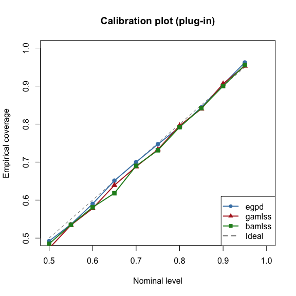

```r
plot(levels, levels, type = "l", lwd = 1, col = "grey50", lty = 2,
     xlab = "Nominal level", ylab = "Empirical coverage",
     main = "Calibration plot (plug-in)", xlim = c(0.5, 1), ylim = c(0.5, 1))
points(levels, cov_e_levels, pch = 16, col = "steelblue", cex = 1.2)
lines(levels, cov_e_levels, col = "steelblue", lwd = 2)
points(levels, cov_g_levels, pch = 17, col = "firebrick", cex = 1.2)
lines(levels, cov_g_levels, col = "firebrick", lwd = 2)
points(levels, cov_b_levels, pch = 15, col = "forestgreen", cex = 1.2)
lines(levels, cov_b_levels, col = "forestgreen", lwd = 2)
legend("bottomright",
       legend = c("egpd", "gamlss", "bamlss", "Ideal"),
       col = c("steelblue", "firebrick", "forestgreen", "grey50"),
       pch = c(16, 17, 15, NA), lty = c(1, 1, 1, 2), lwd = 2)
```

### Calibration plot: parametric prediction

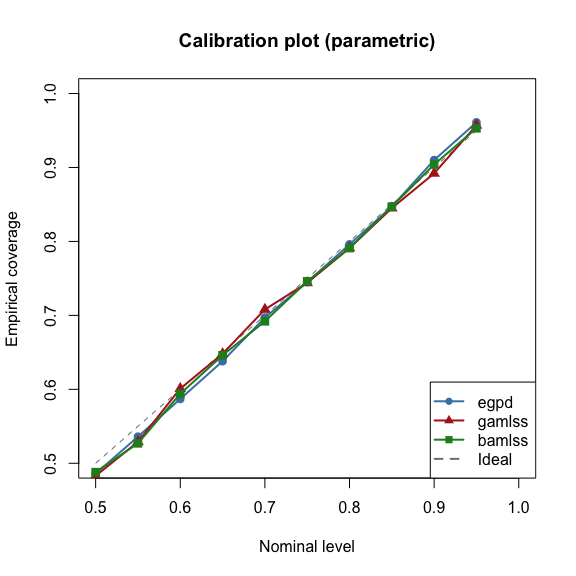

```r
plot(levels, levels, type = "l", lwd = 1, col = "grey50", lty = 2,
     xlab = "Nominal level", ylab = "Empirical coverage",
     main = "Calibration plot (parametric)", xlim = c(0.5, 1), ylim = c(0.5, 1))
points(levels, cov_e_par_levels, pch = 16, col = "steelblue", cex = 1.2)
lines(levels, cov_e_par_levels, col = "steelblue", lwd = 2)
points(levels, cov_g_par_levels, pch = 17, col = "firebrick", cex = 1.2)
lines(levels, cov_g_par_levels, col = "firebrick", lwd = 2)
points(levels, cov_b_par_levels, pch = 15, col = "forestgreen", cex = 1.2)
lines(levels, cov_b_par_levels, col = "forestgreen", lwd = 2)
legend("bottomright",
       legend = c("egpd", "gamlss", "bamlss", "Ideal"),
       col = c("steelblue", "firebrick", "forestgreen", "grey50"),
       pch = c(16, 17, 15, NA), lty = c(1, 1, 1, 2), lwd = 2)
```

Both plots show that all three fitting approaches are well-calibrated, with empirical coverage closely tracking the nominal level. The small deviations are expected for discrete data — the integer-valued nature of the response means that exact coverage at every level is not achievable.

## 5. Calibration with a covariate-dependent model

To demonstrate coverage assessment with covariates, we simulate discrete EGPD data where the scale parameter varies smoothly with a covariate `x`.

```r
set.seed(7)
n <- 1000
x <- runif(n, 0, 1)
sigma_x <- exp(1 + 2 * x)
xi_true  <- 0.3
kappa_true <- 1.5

y_s <- rdiscegpd(n, sigma = sigma_x, xi = xi_true,
                 kappa = kappa_true, type = 1)
df_s <- data.frame(y = y_s, x = x)
```

### Fit with smooth terms

```r
fit_es <- egpd(list(lsigma = y ~ s(x, k = 10), lxi = ~ 1, lkappa = ~ 1),
               data = df_s, family = "degpd", degpd.args = list(m = 1))

fit_gs <- gamlss(y ~ pb(x), sigma.formula = ~ 1, nu.formula = ~ 1,
                 data = df_s, family = DEGPD1(),
                 control = gamlss.control(n.cyc = 200, trace = FALSE))

fit_bs <- bamlss(list(y ~ s(x, k = 10), ~ 1, ~ 1),
                 data = df_s, family = degpd_bamlss(m = 1),
                 verbose = FALSE)
```

### Calibration across levels

```r
set.seed(3)
levels_s <- seq(0.50, 0.99, by = 0.05)
nsim_s <- 3000

cov_es <- multi_coverage(fit_es, y_s, levels_s, nsim_s, "plug-in")
cov_gs <- multi_coverage(fit_gs, y_s, levels_s, nsim_s, "plug-in")
cov_bs <- multi_coverage(fit_bs, y_s, levels_s, nsim_s, "plug-in")
```

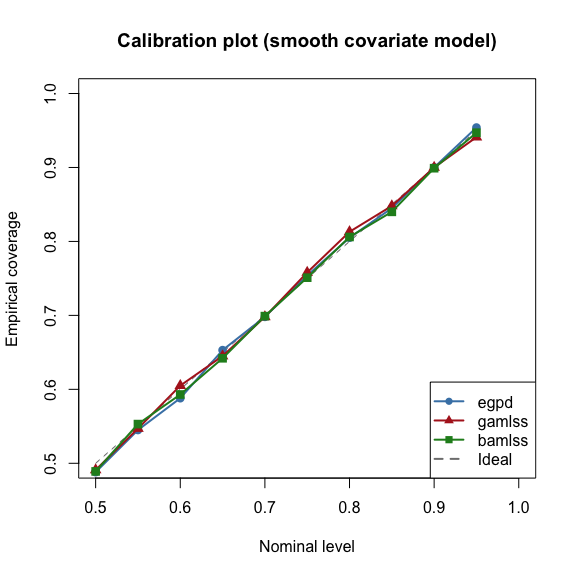

```r
plot(levels_s, levels_s, type = "l", lwd = 1, col = "grey50", lty = 2,
     xlab = "Nominal level", ylab = "Empirical coverage",
     main = "Calibration plot (smooth covariate model)",
     xlim = c(0.5, 1), ylim = c(0.5, 1))
points(levels_s, cov_es, pch = 16, col = "steelblue", cex = 1.2)
lines(levels_s, cov_es, col = "steelblue", lwd = 2)
points(levels_s, cov_gs, pch = 17, col = "firebrick", cex = 1.2)
lines(levels_s, cov_gs, col = "firebrick", lwd = 2)
points(levels_s, cov_bs, pch = 15, col = "forestgreen", cex = 1.2)
lines(levels_s, cov_bs, col = "forestgreen", lwd = 2)
legend("bottomright",
       legend = c("egpd", "gamlss", "bamlss", "Ideal"),
       col = c("steelblue", "firebrick", "forestgreen", "grey50"),
       pch = c(16, 17, 15, NA), lty = c(1, 1, 1, 2), lwd = 2)
```

Even with covariate-dependent parameters, all three fitting approaches produce well-calibrated prediction intervals.

## 6. Out-of-sample forecast evaluation

The previous sections assessed **in-sample** coverage: the prediction intervals were evaluated on the same data used to fit the model. A more stringent test is **out-of-sample** (forecast) coverage, where we hold out observations that the model has never seen. This is the relevant metric for real forecasting applications.

We simulate a larger covariate-dependent dataset, hold out the last 200 observations as a test set, fit on the training set, and evaluate coverage on the held-out data via `newdata`.

### Simulate train/test split

```r
set.seed(10)
n_total <- 1200
n_test  <- 200
n_train <- n_total - n_test

x_all <- seq(0, 1, length.out = n_total)
sigma_all <- exp(1 + 2 * x_all)
xi_true_f  <- 0.3
kappa_true_f <- 1.5

y_all <- rdiscegpd(n_total, sigma = sigma_all, xi = xi_true_f,
                   kappa = kappa_true_f, type = 1)
df_all <- data.frame(y = y_all, x = x_all)

df_train <- df_all[1:n_train, ]
df_test  <- df_all[(n_train + 1):n_total, ]
y_test   <- df_test$y

cat("Training set: n =", n_train, "\n")
```

```
#> Training set: n = 1000
```

```r
cat("Test set:     n =", n_test, "\n")
```

```
#> Test set:     n = 200
```

```r
cat("Test x range:", round(range(df_test$x), 3), "\n")
```

```
#> Test x range: 0.834 1
```

### Fit models on training data only

```r
fit_e_tr <- egpd(list(lsigma = y ~ s(x, k = 10), lxi = ~ 1, lkappa = ~ 1),
                 data = df_train, family = "degpd", degpd.args = list(m = 1))

fit_g_tr <- gamlss(y ~ pb(x), sigma.formula = ~ 1, nu.formula = ~ 1,
                   data = df_train, family = DEGPD1(),
                   control = gamlss.control(n.cyc = 200, trace = FALSE))

fit_b_tr <- bamlss(list(y ~ s(x, k = 10), ~ 1, ~ 1),
                   data = df_train, family = degpd_bamlss(m = 1),
                   verbose = FALSE)
```

### Out-of-sample coverage at 95%

We pass `newdata = df_test` so that predictions are made at the test-set covariate values, and compare against the held-out responses `y_test`.

```r
set.seed(5)
nsim_f <- 3000

fcov_e_pi  <- predictive_coverage(fit_e_tr, y_test, newdata = df_test,
                                   nsim = nsim_f, method = "plug-in")
fcov_e_par <- predictive_coverage(fit_e_tr, y_test, newdata = df_test,
                                   nsim = nsim_f, method = "parametric")

fcov_g_pi  <- predictive_coverage(fit_g_tr, y_test, newdata = df_test,
                                   nsim = nsim_f, method = "plug-in")
fcov_g_par <- predictive_coverage(fit_g_tr, y_test, newdata = df_test,
                                   nsim = nsim_f, method = "parametric")

fcov_b_pi  <- predictive_coverage(fit_b_tr, y_test, newdata = df_test,
                                   nsim = nsim_f, method = "plug-in")
fcov_b_par <- predictive_coverage(fit_b_tr, y_test, newdata = df_test,
                                   nsim = nsim_f, method = "parametric")

data.frame(
  approach    = rep(c("egpd", "gamlss", "bamlss"), each = 2),
  method      = rep(c("plug-in", "parametric"), 3),
  coverage    = round(c(fcov_e_pi$coverage, fcov_e_par$coverage,
                        fcov_g_pi$coverage, fcov_g_par$coverage,
                        fcov_b_pi$coverage, fcov_b_par$coverage), 4),
  nominal     = 0.95,
  row.names   = NULL
)
```

```
#>   approach     method coverage nominal
#> 1     egpd    plug-in    0.960    0.95
#> 2     egpd parametric    0.960    0.95
#> 3   gamlss    plug-in    0.945    0.95
#> 4   gamlss parametric    0.950    0.95
#> 5   bamlss    plug-in    0.955    0.95
#> 6   bamlss parametric    0.960    0.95
```

### Forecast calibration across levels

```r
set.seed(6)
levels_f <- seq(0.50, 0.99, by = 0.05)
nsim_fc  <- 3000

multi_coverage_oos <- function(fit, y, newdata, levels, nsim, method) {
  vapply(levels, function(lv) {
    predictive_coverage(fit, y, newdata = newdata, level = lv,
                        nsim = nsim, method = method)$coverage
  }, numeric(1))
}

# Plug-in
fcov_e_lev <- multi_coverage_oos(fit_e_tr, y_test, df_test, levels_f, nsim_fc, "plug-in")
fcov_g_lev <- multi_coverage_oos(fit_g_tr, y_test, df_test, levels_f, nsim_fc, "plug-in")
fcov_b_lev <- multi_coverage_oos(fit_b_tr, y_test, df_test, levels_f, nsim_fc, "plug-in")

# Parametric
fcov_e_par_lev <- multi_coverage_oos(fit_e_tr, y_test, df_test, levels_f, nsim_fc, "parametric")
fcov_g_par_lev <- multi_coverage_oos(fit_g_tr, y_test, df_test, levels_f, nsim_fc, "parametric")
fcov_b_par_lev <- multi_coverage_oos(fit_b_tr, y_test, df_test, levels_f, nsim_fc, "parametric")
```

### Forecast calibration plot: plug-in

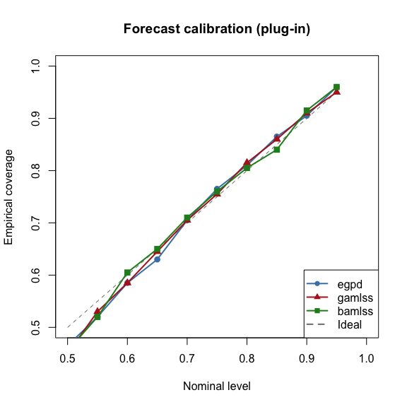

```r
plot(levels_f, levels_f, type = "l", lwd = 1, col = "grey50", lty = 2,
     xlab = "Nominal level", ylab = "Empirical coverage",
     main = "Forecast calibration (plug-in)",
     xlim = c(0.5, 1), ylim = c(0.5, 1))
points(levels_f, fcov_e_lev, pch = 16, col = "steelblue", cex = 1.2)
lines(levels_f, fcov_e_lev, col = "steelblue", lwd = 2)
points(levels_f, fcov_g_lev, pch = 17, col = "firebrick", cex = 1.2)
lines(levels_f, fcov_g_lev, col = "firebrick", lwd = 2)
points(levels_f, fcov_b_lev, pch = 15, col = "forestgreen", cex = 1.2)
lines(levels_f, fcov_b_lev, col = "forestgreen", lwd = 2)
legend("bottomright",
       legend = c("egpd", "gamlss", "bamlss", "Ideal"),
       col = c("steelblue", "firebrick", "forestgreen", "grey50"),
       pch = c(16, 17, 15, NA), lty = c(1, 1, 1, 2), lwd = 2)
```

### Forecast calibration plot: parametric

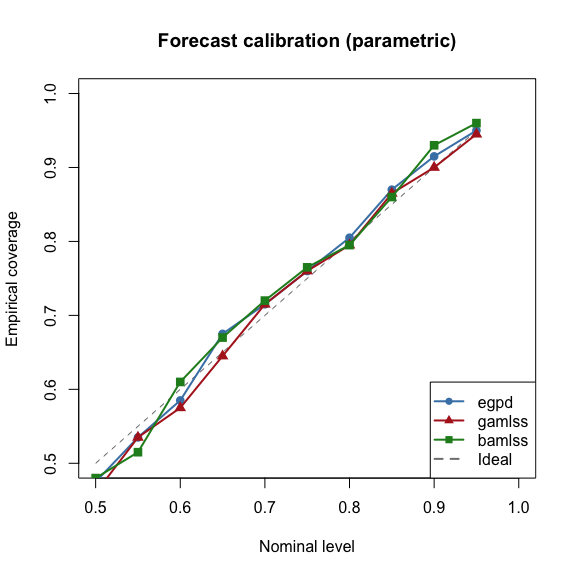

```r
plot(levels_f, levels_f, type = "l", lwd = 1, col = "grey50", lty = 2,
     xlab = "Nominal level", ylab = "Empirical coverage",
     main = "Forecast calibration (parametric)",
     xlim = c(0.5, 1), ylim = c(0.5, 1))
points(levels_f, fcov_e_par_lev, pch = 16, col = "steelblue", cex = 1.2)
lines(levels_f, fcov_e_par_lev, col = "steelblue", lwd = 2)
points(levels_f, fcov_g_par_lev, pch = 17, col = "firebrick", cex = 1.2)
lines(levels_f, fcov_g_par_lev, col = "firebrick", lwd = 2)
points(levels_f, fcov_b_par_lev, pch = 15, col = "forestgreen", cex = 1.2)
lines(levels_f, fcov_b_par_lev, col = "forestgreen", lwd = 2)
legend("bottomright",
       legend = c("egpd", "gamlss", "bamlss", "Ideal"),
       col = c("steelblue", "firebrick", "forestgreen", "grey50"),
       pch = c(16, 17, 15, NA), lty = c(1, 1, 1, 2), lwd = 2)
```

### Forecast prediction intervals vs observations

A useful visual check is to plot the prediction intervals alongside the held-out observations. Points falling outside the interval are highlighted.

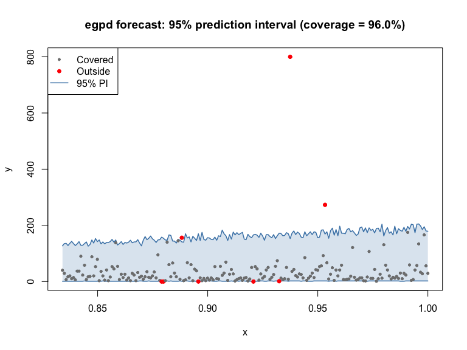

```r
# Use egpd parametric intervals for illustration
cov_plot <- fcov_e_par

outside <- !cov_plot$covered
x_test <- df_test$x

plot(x_test, y_test, pch = 20, col = ifelse(outside, "red", "grey50"),
     cex = ifelse(outside, 1.2, 0.8),
     xlab = "x", ylab = "y",
     main = sprintf("egpd forecast: 95%% prediction interval (coverage = %.1f%%)",
                    100 * cov_plot$coverage))
# Shade the prediction band
ord <- order(x_test)
polygon(c(x_test[ord], rev(x_test[ord])),
        c(cov_plot$L[ord], rev(cov_plot$U[ord])),
        col = adjustcolor("steelblue", alpha.f = 0.2), border = NA)
lines(x_test[ord], cov_plot$L[ord], col = "steelblue", lwd = 1.5)
lines(x_test[ord], cov_plot$U[ord], col = "steelblue", lwd = 1.5)
# Re-draw points on top
points(x_test, y_test, pch = 20, col = ifelse(outside, "red", "grey50"),
       cex = ifelse(outside, 1.2, 0.8))
legend("topleft",
       legend = c("Covered", "Outside", "95% PI"),
       col = c("grey50", "red", "steelblue"),
       pch = c(20, 20, NA), lty = c(NA, NA, 1), lwd = c(NA, NA, 1.5),
       pt.cex = c(0.8, 1.2, NA))
```

The prediction band widens with `x`, reflecting the increasing scale parameter. Held-out observations that fall outside the interval (red) are roughly 5% of the total, matching the nominal level.

### In-sample vs out-of-sample comparison

```r
set.seed(7)
# In-sample coverage on training data
cov_in_e <- predictive_coverage(fit_e_tr, df_train$y,
                                 nsim = nsim_f, method = "parametric")
cov_in_g <- predictive_coverage(fit_g_tr, df_train$y,
                                 nsim = nsim_f, method = "parametric")
cov_in_b <- predictive_coverage(fit_b_tr, df_train$y,
                                 nsim = nsim_f, method = "parametric")

data.frame(
  approach    = rep(c("egpd", "gamlss", "bamlss"), each = 2),
  evaluation  = rep(c("in-sample", "out-of-sample"), 3),
  coverage    = round(c(cov_in_e$coverage, fcov_e_par$coverage,
                        cov_in_g$coverage, fcov_g_par$coverage,
                        cov_in_b$coverage, fcov_b_par$coverage), 4),
  nominal     = 0.95,
  row.names   = NULL
)
```

```
#>   approach    evaluation coverage nominal
#> 1     egpd     in-sample    0.935    0.95
#> 2     egpd out-of-sample    0.960    0.95
#> 3   gamlss     in-sample    0.945    0.95
#> 4   gamlss out-of-sample    0.950    0.95
#> 5   bamlss     in-sample    0.944    0.95
#> 6   bamlss out-of-sample    0.960    0.95
```

## 7. Shortest vs equal-tailed intervals

For discrete data, equal-tailed intervals may not be optimal because the probability mass is concentrated on integers. The `use_shortest = TRUE` option computes the shortest (highest density region) interval instead.

```r
set.seed(4)

cov_eq  <- predictive_coverage(fit_e, y, level = 0.95, nsim = 3000,
                                method = "plug-in", use_shortest = FALSE)
cov_hdr <- predictive_coverage(fit_e, y, level = 0.95, nsim = 3000,
                                method = "plug-in", use_shortest = TRUE)

data.frame(
  interval_type    = c("Equal-tailed", "Shortest (HDR)"),
  coverage         = round(c(cov_eq$coverage, cov_hdr$coverage), 4),
  mean_width       = round(c(mean(cov_eq$U - cov_eq$L),
                              mean(cov_hdr$U - cov_hdr$L)), 2),
  row.names        = NULL
)
```

```
#>    interval_type coverage mean_width
#> 1   Equal-tailed    0.948      16.61
#> 2 Shortest (HDR)    0.955      13.85
```

The shortest interval achieves similar coverage with narrower (or equal) interval width, making it the more efficient choice for discrete data.